# Risk Factor Analysis

## Outcome Variable

**Outcome Variable:** stunted

## Predictor Variables

**Intervention Variable:** mage

**Adjustment Set:**

unadjusted

## Stratifying Variables

The analysis was stratified on these variable(s):

- agecat
- studyid
- country

## Data Summary

| agecat | studyid | country | mage | stunted | n_cell | n |
| --- | --- | --- | --- | --- | --- | --- |
| Birth | ki0047075b-MAL-ED | BANGLADESH | <25 | 0 | 97 | 257 |
| Birth | ki0047075b-MAL-ED | BANGLADESH | <25 | 1 | 23 | 257 |
| Birth | ki0047075b-MAL-ED | BANGLADESH | [25-30) | 0 | 77 | 257 |
| Birth | ki0047075b-MAL-ED | BANGLADESH | [25-30) | 1 | 15 | 257 |
| Birth | ki0047075b-MAL-ED | BANGLADESH | >=30 | 0 | 36 | 257 |
| Birth | ki0047075b-MAL-ED | BANGLADESH | >=30 | 1 | 9 | 257 |
| Birth | ki0047075b-MAL-ED | BRAZIL | <25 | 0 | 88 | 191 |
| Birth | ki0047075b-MAL-ED | BRAZIL | <25 | 1 | 9 | 191 |
| Birth | ki0047075b-MAL-ED | BRAZIL | [25-30) | 0 | 45 | 191 |
| Birth | ki0047075b-MAL-ED | BRAZIL | [25-30) | 1 | 9 | 191 |
| Birth | ki0047075b-MAL-ED | BRAZIL | >=30 | 0 | 37 | 191 |
| Birth | ki0047075b-MAL-ED | BRAZIL | >=30 | 1 | 3 | 191 |
| Birth | ki0047075b-MAL-ED | INDIA | <25 | 0 | 100 | 205 |
| Birth | ki0047075b-MAL-ED | INDIA | <25 | 1 | 22 | 205 |
| Birth | ki0047075b-MAL-ED | INDIA | [25-30) | 0 | 59 | 205 |
| Birth | ki0047075b-MAL-ED | INDIA | [25-30) | 1 | 9 | 205 |
| Birth | ki0047075b-MAL-ED | INDIA | >=30 | 0 | 14 | 205 |
| Birth | ki0047075b-MAL-ED | INDIA | >=30 | 1 | 1 | 205 |
| Birth | ki0047075b-MAL-ED | NEPAL | <25 | 0 | 40 | 173 |
| Birth | ki0047075b-MAL-ED | NEPAL | <25 | 1 | 6 | 173 |
| Birth | ki0047075b-MAL-ED | NEPAL | [25-30) | 0 | 83 | 173 |
| Birth | ki0047075b-MAL-ED | NEPAL | [25-30) | 1 | 8 | 173 |
| Birth | ki0047075b-MAL-ED | NEPAL | >=30 | 0 | 32 | 173 |
| Birth | ki0047075b-MAL-ED | NEPAL | >=30 | 1 | 4 | 173 |
| Birth | ki0047075b-MAL-ED | PERU | <25 | 0 | 139 | 287 |
| Birth | ki0047075b-MAL-ED | PERU | <25 | 1 | 22 | 287 |
| Birth | ki0047075b-MAL-ED | PERU | [25-30) | 0 | 57 | 287 |
| Birth | ki0047075b-MAL-ED | PERU | [25-30) | 1 | 4 | 287 |
| Birth | ki0047075b-MAL-ED | PERU | >=30 | 0 | 57 | 287 |
| Birth | ki0047075b-MAL-ED | PERU | >=30 | 1 | 8 | 287 |

[output cut: 378 more lines]

The following strata were considered:

- agecat: 24 months, studyid: ki0047075b-MAL-ED, country: BANGLADESH
- agecat: 24 months, studyid: ki0047075b-MAL-ED, country: BRAZIL
- agecat: 24 months, studyid: ki0047075b-MAL-ED, country: INDIA
- agecat: 24 months, studyid: ki0047075b-MAL-ED, country: NEPAL
- agecat: 24 months, studyid: ki0047075b-MAL-ED, country: PERU
- agecat: 24 months, studyid: ki0047075b-MAL-ED, country: SOUTH AFRICA
- agecat: 24 months, studyid: ki0047075b-MAL-ED, country: TANZANIA, UNITED REPUBLIC OF
- agecat: 24 months, studyid: ki1000108-CMC-V-BCS-2002, country: INDIA
- agecat: 24 months, studyid: ki1000108-IRC, country: INDIA
- agecat: 24 months, studyid: ki1017093-NIH-Birth, country: BANGLADESH
- agecat: 24 months, studyid: ki1017093b-PROVIDE, country: BANGLADESH
- agecat: 24 months, studyid: ki1017093c-NIH-Crypto, country: BANGLADESH
- agecat: 24 months, studyid: ki1066203-TanzaniaChild2, country: TANZANIA, UNITED REPUBLIC OF
- agecat: 24 months, studyid: ki1101329-Keneba, country: GAMBIA
- agecat: 24 months, studyid: ki1113344-GMS-Nepal, country: NEPAL
- agecat: 24 months, studyid: ki1119695-PROBIT, country: BELARUS
- agecat: 24 months, studyid: ki1126311-ZVITAMBO, country: ZIMBABWE
- agecat: 24 months, studyid: ki1135781-COHORTS, country: GUATEMALA
- agecat: 24 months, studyid: ki1135781-COHORTS, country: INDIA
- agecat: 24 months, studyid: ki1135781-COHORTS, country: PHILIPPINES
- agecat: 24 months, studyid: ki1148112-LCNI-5, country: MALAWI
- agecat: 24 months, studyid: kiGH5241-JiVitA-3, country: BANGLADESH
- agecat: 6 months, studyid: ki0047075b-MAL-ED, country: BANGLADESH
- agecat: 6 months, studyid: ki0047075b-MAL-ED, country: BRAZIL
- agecat: 6 months, studyid: ki0047075b-MAL-ED, country: INDIA
- agecat: 6 months, studyid: ki0047075b-MAL-ED, country: NEPAL
- agecat: 6 months, studyid: ki0047075b-MAL-ED, country: PERU
- agecat: 6 months, studyid: ki0047075b-MAL-ED, country: SOUTH AFRICA
- agecat: 6 months, studyid: ki0047075b-MAL-ED, country: TANZANIA, UNITED REPUBLIC OF
- agecat: 6 months, studyid: ki1000108-CMC-V-BCS-2002, country: INDIA
- agecat: 6 months, studyid: ki1000108-IRC, country: INDIA
- agecat: 6 months, studyid: ki1000109-EE, country: PAKISTAN
- agecat: 6 months, studyid: ki1000304b-SAS-CompFeed, country: INDIA
- agecat: 6 months, studyid: ki1000304b-SAS-FoodSuppl, country: INDIA
- agecat: 6 months, studyid: ki1017093-NIH-Birth, country: BANGLADESH
- agecat: 6 months, studyid: ki1017093b-PROVIDE, country: BANGLADESH
- agecat: 6 months, studyid: ki1017093c-NIH-Crypto, country: BANGLADESH
- agecat: 6 months, studyid: ki1066203-TanzaniaChild2, country: TANZANIA, UNITED REPUBLIC OF
- agecat: 6 months, studyid: ki1101329-Keneba, country: GAMBIA
- agecat: 6 months, studyid: ki1112895-Guatemala BSC, country: GUATEMALA
- agecat: 6 months, studyid: ki1113344-GMS-Nepal, country: NEPAL
- agecat: 6 months, studyid: ki1119695-PROBIT, country: BELARUS
- agecat: 6 months, studyid: ki1126311-ZVITAMBO, country: ZIMBABWE
- agecat: 6 months, studyid: ki1135781-COHORTS, country: GUATEMALA
- agecat: 6 months, studyid: ki1135781-COHORTS, country: INDIA
- agecat: 6 months, studyid: ki1135781-COHORTS, country: PHILIPPINES
- agecat: 6 months, studyid: ki1148112-LCNI-5, country: MALAWI
- agecat: 6 months, studyid: kiGH5241-JiVitA-3, country: BANGLADESH
- agecat: Birth, studyid: ki0047075b-MAL-ED, country: BANGLADESH
- agecat: Birth, studyid: ki0047075b-MAL-ED, country: BRAZIL
- agecat: Birth, studyid: ki0047075b-MAL-ED, country: INDIA
- agecat: Birth, studyid: ki0047075b-MAL-ED, country: NEPAL
- agecat: Birth, studyid: ki0047075b-MAL-ED, country: PERU
- agecat: Birth, studyid: ki0047075b-MAL-ED, country: SOUTH AFRICA
- agecat: Birth, studyid: ki0047075b-MAL-ED, country: TANZANIA, UNITED REPUBLIC OF
- agecat: Birth, studyid: ki1000108-CMC-V-BCS-2002, country: INDIA
- agecat: Birth, studyid: ki1000108-IRC, country: INDIA
- agecat: Birth, studyid: ki1000109-EE, country: PAKISTAN
- agecat: Birth, studyid: ki1000304b-SAS-CompFeed, country: INDIA
- agecat: Birth, studyid: ki1017093-NIH-Birth, country: BANGLADESH
- agecat: Birth, studyid: ki1017093c-NIH-Crypto, country: BANGLADESH
- agecat: Birth, studyid: ki1101329-Keneba, country: GAMBIA
- agecat: Birth, studyid: ki1119695-PROBIT, country: BELARUS
- agecat: Birth, studyid: ki1126311-ZVITAMBO, country: ZIMBABWE
- agecat: Birth, studyid: ki1135781-COHORTS, country: GUATEMALA
- agecat: Birth, studyid: ki1135781-COHORTS, country: INDIA
- agecat: Birth, studyid: ki1135781-COHORTS, country: PHILIPPINES
- agecat: Birth, studyid: kiGH5241-JiVitA-3, country: BANGLADESH

### Dropped Strata

Some strata were dropped due to rare outcomes:

- agecat: Birth, studyid: ki0047075b-MAL-ED, country: BRAZIL
- agecat: Birth, studyid: ki0047075b-MAL-ED, country: INDIA
- agecat: Birth, studyid: ki0047075b-MAL-ED, country: NEPAL
- agecat: Birth, studyid: ki0047075b-MAL-ED, country: PERU
- agecat: Birth, studyid: ki0047075b-MAL-ED, country: SOUTH AFRICA
- agecat: Birth, studyid: ki0047075b-MAL-ED, country: TANZANIA, UNITED REPUBLIC OF
- agecat: Birth, studyid: ki1000108-CMC-V-BCS-2002, country: INDIA
- agecat: Birth, studyid: ki1000108-IRC, country: INDIA
- agecat: Birth, studyid: ki1000109-EE, country: PAKISTAN
- agecat: Birth, studyid: ki1000304b-SAS-CompFeed, country: INDIA
- agecat: Birth, studyid: ki1017093-NIH-Birth, country: BANGLADESH
- agecat: Birth, studyid: ki1017093c-NIH-Crypto, country: BANGLADESH
- agecat: Birth, studyid: ki1119695-PROBIT, country: BELARUS
- agecat: 6 months, studyid: ki0047075b-MAL-ED, country: BRAZIL
- agecat: 6 months, studyid: ki0047075b-MAL-ED, country: INDIA
- agecat: 6 months, studyid: ki0047075b-MAL-ED, country: NEPAL
- agecat: 24 months, studyid: ki0047075b-MAL-ED, country: BRAZIL
- agecat: 24 months, studyid: ki0047075b-MAL-ED, country: INDIA
- agecat: 24 months, studyid: ki1066203-TanzaniaChild2, country: TANZANIA, UNITED REPUBLIC OF

## Methods Detail

We’re interested in the causal parameters $E[Y_a]$ for all values of $a \in \mathcal{A}$. These parameters represent the mean outcome if, possibly contrary to fact, we intervened to set all units to have $A=a$. Under the randomization and positivity assumptions, these are identified by the statistical parameters $\psi_a=E_W[E_{Y|A,W}(Y|A=a,W)]$. In addition, we’re interested in the mean of $Y$, $E[Y]$ under no intervention (the observed mean). We will estimate these parameters by using SuperLearner to fit the relevant likelihood factors – $E_{Y|A,W}(Y|A=a,W)$ and $p(A=a|W)$, and then updating our likelihood fit using a joint TMLE.

For unadjusted analyses ($W=\{\}$), initial likelihoods were estimated using Lrnr_glm to estimate the simple $E(Y|A)$ and Lrnr_mean to estimate $p(A)$. For adjusted analyses, a small library containing Lrnr_glmnet, Lrnr_xgboost, and Lrnr_mean was used.

Having estimated these parameters, we will then use the delta method to estimate relative risks and attributable risks relative to a prespecified baseline level of $A$.

# Results Detail

## Results Plots

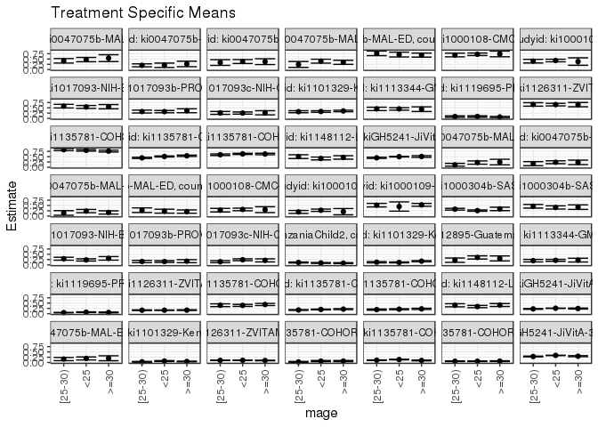

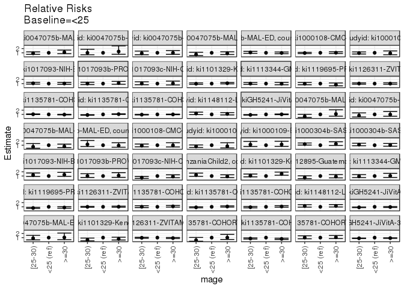

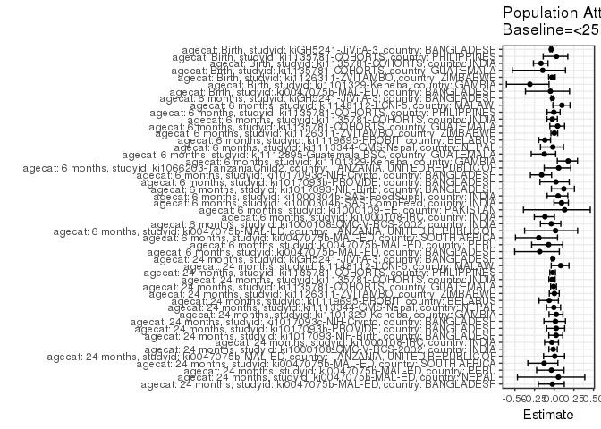

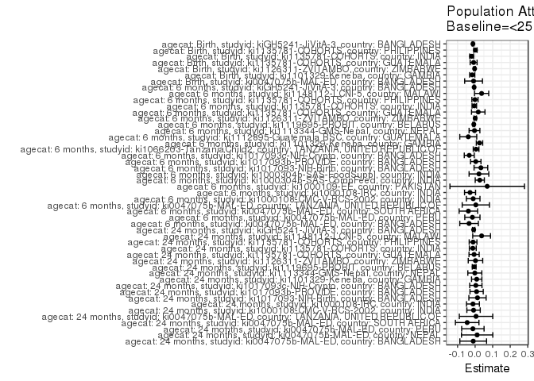

## Results Table

### Parameter: TSM

| agecat | studyid | country | intervention_level | baseline_level | estimate | ci_lower | ci_upper |
| --- | --- | --- | --- | --- | --- | --- | --- |
| Birth | ki0047075b-MAL-ED | BANGLADESH | <25 | NA | 0.1916667 | 0.1211044 | 0.2622289 |
| Birth | ki0047075b-MAL-ED | BANGLADESH | [25-30) | NA | 0.1630435 | 0.0874118 | 0.2386752 |
| Birth | ki0047075b-MAL-ED | BANGLADESH | >=30 | NA | 0.2000000 | 0.0829023 | 0.3170977 |
| Birth | ki1101329-Keneba | GAMBIA | <25 | NA | 0.0696517 | 0.0493273 | 0.0899762 |
| Birth | ki1101329-Keneba | GAMBIA | [25-30) | NA | 0.0323529 | 0.0135396 | 0.0511662 |
| Birth | ki1101329-Keneba | GAMBIA | >=30 | NA | 0.0484950 | 0.0312726 | 0.0657173 |
| Birth | ki1126311-ZVITAMBO | ZIMBABWE | <25 | NA | 0.1063061 | 0.0995617 | 0.1130505 |
| Birth | ki1126311-ZVITAMBO | ZIMBABWE | [25-30) | NA | 0.1022661 | 0.0921434 | 0.1123889 |
| Birth | ki1126311-ZVITAMBO | ZIMBABWE | >=30 | NA | 0.0950947 | 0.0831678 | 0.1070215 |
| Birth | ki1135781-COHORTS | GUATEMALA | <25 | NA | 0.0672515 | 0.0406918 | 0.0938112 |
| Birth | ki1135781-COHORTS | GUATEMALA | [25-30) | NA | 0.0271739 | 0.0036674 | 0.0506804 |
| Birth | ki1135781-COHORTS | GUATEMALA | >=30 | NA | 0.0674847 | 0.0402373 | 0.0947320 |
| Birth | ki1135781-COHORTS | INDIA | <25 | NA | 0.1381910 | 0.1230270 | 0.1533549 |
| Birth | ki1135781-COHORTS | INDIA | [25-30) | NA | 0.1084724 | 0.0930292 | 0.1239156 |
| Birth | ki1135781-COHORTS | INDIA | >=30 | NA | 0.0976864 | 0.0806509 | 0.1147219 |
| Birth | ki1135781-COHORTS | PHILIPPINES | <25 | NA | 0.0595238 | 0.0468724 | 0.0721752 |
| Birth | ki1135781-COHORTS | PHILIPPINES | [25-30) | NA | 0.0608187 | 0.0447962 | 0.0768412 |
| Birth | ki1135781-COHORTS | PHILIPPINES | >=30 | NA | 0.0646298 | 0.0481078 | 0.0811519 |
| Birth | kiGH5241-JiVitA-3 | BANGLADESH | <25 | NA | 0.3355373 | 0.3267866 | 0.3442880 |
| Birth | kiGH5241-JiVitA-3 | BANGLADESH | [25-30) | NA | 0.2839799 | 0.2668847 | 0.3010750 |
| Birth | kiGH5241-JiVitA-3 | BANGLADESH | >=30 | NA | 0.2981701 | 0.2753380 | 0.3210021 |
| 6 months | ki0047075b-MAL-ED | BANGLADESH | <25 | NA | 0.2212389 | 0.1445479 | 0.2979300 |
| 6 months | ki0047075b-MAL-ED | BANGLADESH | [25-30) | NA | 0.1149425 | 0.0477815 | 0.1821036 |
| 6 months | ki0047075b-MAL-ED | BANGLADESH | >=30 | NA | 0.2439024 | 0.1121811 | 0.3756238 |
| 6 months | ki0047075b-MAL-ED | PERU | <25 | NA | 0.2352941 | 0.1679574 | 0.3026308 |
| 6 months | ki0047075b-MAL-ED | PERU | [25-30) | NA | 0.1694915 | 0.0735813 | 0.2654018 |
| 6 months | ki0047075b-MAL-ED | PERU | >=30 | NA | 0.2295082 | 0.1237867 | 0.3352297 |
| 6 months | ki0047075b-MAL-ED | SOUTH AFRICA | <25 | NA | 0.2352941 | 0.1589309 | 0.3116573 |
| 6 months | ki0047075b-MAL-ED | SOUTH AFRICA | [25-30) | NA | 0.1463415 | 0.0379391 | 0.2547438 |
| 6 months | ki0047075b-MAL-ED | SOUTH AFRICA | >=30 | NA | 0.1702128 | 0.0940890 | 0.2463365 |

[output cut: 117 more lines]

### Parameter: E(Y)

| agecat | studyid | country | intervention_level | baseline_level | estimate | ci_lower | ci_upper |
| --- | --- | --- | --- | --- | --- | --- | --- |
| Birth | ki0047075b-MAL-ED | BANGLADESH | NA | NA | 0.1828794 | 0.1355257 | 0.2302330 |
| Birth | ki1101329-Keneba | GAMBIA | NA | NA | 0.0532122 | 0.0420018 | 0.0644226 |
| Birth | ki1126311-ZVITAMBO | ZIMBABWE | NA | NA | 0.1034083 | 0.0983260 | 0.1084905 |
| Birth | ki1135781-COHORTS | GUATEMALA | NA | NA | 0.0586854 | 0.0428942 | 0.0744767 |
| Birth | ki1135781-COHORTS | INDIA | NA | NA | 0.1183457 | 0.1091247 | 0.1275667 |
| Birth | ki1135781-COHORTS | PHILIPPINES | NA | NA | 0.0613115 | 0.0527962 | 0.0698268 |
| Birth | kiGH5241-JiVitA-3 | BANGLADESH | NA | NA | 0.3231138 | 0.3154608 | 0.3307668 |
| 6 months | ki0047075b-MAL-ED | BANGLADESH | NA | NA | 0.1867220 | 0.1374205 | 0.2360234 |
| 6 months | ki0047075b-MAL-ED | PERU | NA | NA | 0.2197802 | 0.1705687 | 0.2689917 |
| 6 months | ki0047075b-MAL-ED | SOUTH AFRICA | NA | NA | 0.1968504 | 0.1478551 | 0.2458457 |
| 6 months | ki0047075b-MAL-ED | TANZANIA, UNITED REPUBLIC OF | NA | NA | 0.2348178 | 0.1818480 | 0.2877876 |
| 6 months | ki1000108-CMC-V-BCS-2002 | INDIA | NA | NA | 0.3008130 | 0.2539566 | 0.3476694 |
| 6 months | ki1000108-IRC | INDIA | NA | NA | 0.2457002 | 0.2038248 | 0.2875757 |
| 6 months | ki1000109-EE | PAKISTAN | NA | NA | 0.5189189 | 0.4679396 | 0.5698982 |
| 6 months | ki1000304b-SAS-CompFeed | INDIA | NA | NA | 0.2844311 | 0.2666491 | 0.3022132 |
| 6 months | ki1000304b-SAS-FoodSuppl | INDIA | NA | NA | 0.4289474 | 0.3791199 | 0.4787748 |
| 6 months | ki1017093-NIH-Birth | BANGLADESH | NA | NA | 0.2672897 | 0.2297549 | 0.3048246 |
| 6 months | ki1017093b-PROVIDE | BANGLADESH | NA | NA | 0.1612350 | 0.1313580 | 0.1911120 |
| 6 months | ki1017093c-NIH-Crypto | BANGLADESH | NA | NA | 0.2097902 | 0.1799252 | 0.2396552 |
| 6 months | ki1066203-TanzaniaChild2 | TANZANIA, UNITED REPUBLIC OF | NA | NA | 0.0964215 | 0.0835208 | 0.1093221 |
| 6 months | ki1101329-Keneba | GAMBIA | NA | NA | 0.1408654 | 0.1259115 | 0.1558193 |
| 6 months | ki1112895-Guatemala BSC | GUATEMALA | NA | NA | 0.3115942 | 0.2568550 | 0.3663334 |
| 6 months | ki1113344-GMS-Nepal | NEPAL | NA | NA | 0.2113677 | 0.1776128 | 0.2451225 |
| 6 months | ki1119695-PROBIT | BELARUS | NA | NA | 0.0626864 | 0.0488489 | 0.0765239 |
| 6 months | ki1126311-ZVITAMBO | ZIMBABWE | NA | NA | 0.1660628 | 0.1580467 | 0.1740789 |
| 6 months | ki1135781-COHORTS | GUATEMALA | NA | NA | 0.4099896 | 0.3788775 | 0.4411017 |
| 6 months | ki1135781-COHORTS | INDIA | NA | NA | 0.1959625 | 0.1848518 | 0.2070732 |
| 6 months | ki1135781-COHORTS | PHILIPPINES | NA | NA | 0.2112260 | 0.1958496 | 0.2266024 |
| 6 months | ki1148112-LCNI-5 | MALAWI | NA | NA | 0.3736921 | 0.3370052 | 0.4103790 |
| 6 months | kiGH5241-JiVitA-3 | BANGLADESH | NA | NA | 0.2514524 | 0.2433306 | 0.2595742 |
| 24 months | ki0047075b-MAL-ED | BANGLADESH | NA | NA | 0.4622642 | 0.3949918 | 0.5295365 |
| 24 months | ki0047075b-MAL-ED | NEPAL | NA | NA | 0.2149123 | 0.1614774 | 0.2683472 |
| 24 months | ki0047075b-MAL-ED | PERU | NA | NA | 0.3681592 | 0.3013164 | 0.4350020 |
| 24 months | ki0047075b-MAL-ED | SOUTH AFRICA | NA | NA | 0.3529412 | 0.2921001 | 0.4137823 |
| 24 months | ki0047075b-MAL-ED | TANZANIA, UNITED REPUBLIC OF | NA | NA | 0.7149533 | 0.6543278 | 0.7755787 |
| 24 months | ki1000108-CMC-V-BCS-2002 | INDIA | NA | NA | 0.7150538 | 0.6691221 | 0.7609854 |
| 24 months | ki1000108-IRC | INDIA | NA | NA | 0.4156479 | 0.3678270 | 0.4634689 |
| 24 months | ki1017093-NIH-Birth | BANGLADESH | NA | NA | 0.5550351 | 0.5078433 | 0.6022269 |
| 24 months | ki1017093b-PROVIDE | BANGLADESH | NA | NA | 0.3292894 | 0.2909105 | 0.3676684 |
| 24 months | ki1017093c-NIH-Crypto | BANGLADESH | NA | NA | 0.2568093 | 0.2190047 | 0.2946140 |
| 24 months | ki1101329-Keneba | GAMBIA | NA | NA | 0.3348891 | 0.3125397 | 0.3572386 |
| 24 months | ki1113344-GMS-Nepal | NEPAL | NA | NA | 0.4468938 | 0.4032281 | 0.4905594 |
| 24 months | ki1119695-PROBIT | BELARUS | NA | NA | 0.0852540 | 0.0554439 | 0.1150642 |
| 24 months | ki1126311-ZVITAMBO | ZIMBABWE | NA | NA | 0.6535088 | 0.6097853 | 0.6972322 |
| 24 months | ki1135781-COHORTS | GUATEMALA | NA | NA | 0.7919400 | 0.7675726 | 0.8163075 |
| 24 months | ki1135781-COHORTS | INDIA | NA | NA | 0.4944520 | 0.4783291 | 0.5105749 |
| 24 months | ki1135781-COHORTS | PHILIPPINES | NA | NA | 0.6167689 | 0.5974942 | 0.6360437 |
| 24 months | ki1148112-LCNI-5 | MALAWI | NA | NA | 0.4505263 | 0.4057351 | 0.4953175 |
| 24 months | kiGH5241-JiVitA-3 | BANGLADESH | NA | NA | 0.4908806 | 0.4777422 | 0.5040189 |

### Parameter: RR

| agecat | studyid | country | intervention_level | baseline_level | estimate | ci_lower | ci_upper |
| --- | --- | --- | --- | --- | --- | --- | --- |
| Birth | ki0047075b-MAL-ED | BANGLADESH | <25 | <25 | 1.0000000 | 1.0000000 | 1.0000000 |
| Birth | ki0047075b-MAL-ED | BANGLADESH | [25-30) | <25 | 0.8506616 | 0.4705032 | 1.5379815 |
| Birth | ki0047075b-MAL-ED | BANGLADESH | >=30 | <25 | 1.0434783 | 0.5225389 | 2.0837624 |
| Birth | ki1101329-Keneba | GAMBIA | <25 | <25 | 1.0000000 | 1.0000000 | 1.0000000 |
| Birth | ki1101329-Keneba | GAMBIA | [25-30) | <25 | 0.4644958 | 0.2423404 | 0.8903030 |
| Birth | ki1101329-Keneba | GAMBIA | >=30 | <25 | 0.6962494 | 0.4396886 | 1.1025150 |
| Birth | ki1126311-ZVITAMBO | ZIMBABWE | <25 | <25 | 1.0000000 | 1.0000000 | 1.0000000 |
| Birth | ki1126311-ZVITAMBO | ZIMBABWE | [25-30) | <25 | 0.9619969 | 0.8552898 | 1.0820169 |
| Birth | ki1126311-ZVITAMBO | ZIMBABWE | >=30 | <25 | 0.8945365 | 0.7772421 | 1.0295319 |
| Birth | ki1135781-COHORTS | GUATEMALA | <25 | <25 | 1.0000000 | 1.0000000 | 1.0000000 |
| Birth | ki1135781-COHORTS | GUATEMALA | [25-30) | <25 | 0.4040643 | 0.1561233 | 1.0457624 |
| Birth | ki1135781-COHORTS | GUATEMALA | >=30 | <25 | 1.0034676 | 0.5704495 | 1.7651819 |
| Birth | ki1135781-COHORTS | INDIA | <25 | <25 | 1.0000000 | 1.0000000 | 1.0000000 |
| Birth | ki1135781-COHORTS | INDIA | [25-30) | <25 | 0.7849457 | 0.6558053 | 0.9395164 |
| Birth | ki1135781-COHORTS | INDIA | >=30 | <25 | 0.7068942 | 0.5752703 | 0.8686339 |
| Birth | ki1135781-COHORTS | PHILIPPINES | <25 | <25 | 1.0000000 | 1.0000000 | 1.0000000 |
| Birth | ki1135781-COHORTS | PHILIPPINES | [25-30) | <25 | 1.0217544 | 0.7283498 | 1.4333525 |
| Birth | ki1135781-COHORTS | PHILIPPINES | >=30 | <25 | 1.0857814 | 0.7786794 | 1.5140010 |
| Birth | kiGH5241-JiVitA-3 | BANGLADESH | <25 | <25 | 1.0000000 | 1.0000000 | 1.0000000 |
| Birth | kiGH5241-JiVitA-3 | BANGLADESH | [25-30) | <25 | 0.8463436 | 0.7942323 | 0.9018741 |
| Birth | kiGH5241-JiVitA-3 | BANGLADESH | >=30 | <25 | 0.8886346 | 0.8202091 | 0.9627686 |
| 6 months | ki0047075b-MAL-ED | BANGLADESH | <25 | <25 | 1.0000000 | 1.0000000 | 1.0000000 |
| 6 months | ki0047075b-MAL-ED | BANGLADESH | [25-30) | <25 | 0.5195402 | 0.2633688 | 1.0248826 |
| 6 months | ki0047075b-MAL-ED | BANGLADESH | >=30 | <25 | 1.1024390 | 0.5803001 | 2.0943850 |
| 6 months | ki0047075b-MAL-ED | PERU | <25 | <25 | 1.0000000 | 1.0000000 | 1.0000000 |
| 6 months | ki0047075b-MAL-ED | PERU | [25-30) | <25 | 0.7203390 | 0.3820690 | 1.3581008 |
| 6 months | ki0047075b-MAL-ED | PERU | >=30 | <25 | 0.9754098 | 0.5671111 | 1.6776684 |
| 6 months | ki0047075b-MAL-ED | SOUTH AFRICA | <25 | <25 | 1.0000000 | 1.0000000 | 1.0000000 |
| 6 months | ki0047075b-MAL-ED | SOUTH AFRICA | [25-30) | <25 | 0.6219512 | 0.2770327 | 1.3963091 |
| 6 months | ki0047075b-MAL-ED | SOUTH AFRICA | >=30 | <25 | 0.7234043 | 0.4162941 | 1.2570770 |

[output cut: 117 more lines]

### Parameter: PAR

| agecat | studyid | country | intervention_level | baseline_level | estimate | ci_lower | ci_upper |
| --- | --- | --- | --- | --- | --- | --- | --- |
| Birth | ki0047075b-MAL-ED | BANGLADESH | <25 | NA | -0.0087873 | -0.0594994 | 0.0419249 |
| Birth | ki1101329-Keneba | GAMBIA | <25 | NA | -0.0164395 | -0.0311185 | -0.0017605 |
| Birth | ki1126311-ZVITAMBO | ZIMBABWE | <25 | NA | -0.0028978 | -0.0071852 | 0.0013895 |
| Birth | ki1135781-COHORTS | GUATEMALA | <25 | NA | -0.0085660 | -0.0282754 | 0.0111434 |
| Birth | ki1135781-COHORTS | INDIA | <25 | NA | -0.0198452 | -0.0308394 | -0.0088511 |
| Birth | ki1135781-COHORTS | PHILIPPINES | <25 | NA | 0.0017877 | -0.0077783 | 0.0113536 |
| Birth | kiGH5241-JiVitA-3 | BANGLADESH | <25 | NA | -0.0124235 | -0.0166506 | -0.0081964 |
| 6 months | ki0047075b-MAL-ED | BANGLADESH | <25 | NA | -0.0345169 | -0.0874008 | 0.0183669 |
| 6 months | ki0047075b-MAL-ED | PERU | <25 | NA | -0.0155139 | -0.0587999 | 0.0277721 |
| 6 months | ki0047075b-MAL-ED | SOUTH AFRICA | <25 | NA | -0.0384437 | -0.0910542 | 0.0141668 |
| 6 months | ki0047075b-MAL-ED | TANZANIA, UNITED REPUBLIC OF | <25 | NA | 0.0040486 | -0.0736677 | 0.0817649 |
| 6 months | ki1000108-CMC-V-BCS-2002 | INDIA | <25 | NA | -0.0111136 | -0.0499330 | 0.0277058 |
| 6 months | ki1000108-IRC | INDIA | <25 | NA | -0.0288096 | -0.0603124 | 0.0026933 |
| 6 months | ki1000109-EE | PAKISTAN | <25 | NA | 0.0689189 | -0.1434783 | 0.2813162 |
| 6 months | ki1000304b-SAS-CompFeed | INDIA | <25 | NA | 0.0265998 | 0.0005823 | 0.0526173 |
| 6 months | ki1000304b-SAS-FoodSuppl | INDIA | <25 | NA | 0.0217617 | -0.0344227 | 0.0779462 |
| 6 months | ki1017093-NIH-Birth | BANGLADESH | <25 | NA | 0.0329147 | -0.0061345 | 0.0719639 |
| 6 months | ki1017093b-PROVIDE | BANGLADESH | <25 | NA | 0.0037007 | -0.0261260 | 0.0335275 |
| 6 months | ki1017093c-NIH-Crypto | BANGLADESH | <25 | NA | -0.0335253 | -0.0618893 | -0.0051613 |
| 6 months | ki1066203-TanzaniaChild2 | TANZANIA, UNITED REPUBLIC OF | <25 | NA | 0.0055124 | -0.0107110 | 0.0217358 |
| 6 months | ki1101329-Keneba | GAMBIA | <25 | NA | 0.0251018 | 0.0069405 | 0.0432632 |
| 6 months | ki1112895-Guatemala BSC | GUATEMALA | <25 | NA | -0.0390551 | -0.0873818 | 0.0092715 |
| 6 months | ki1113344-GMS-Nepal | NEPAL | <25 | NA | -0.0036160 | -0.0344017 | 0.0271696 |
| 6 months | ki1119695-PROBIT | BELARUS | <25 | NA | -0.0074109 | -0.0124814 | -0.0023404 |
| 6 months | ki1126311-ZVITAMBO | ZIMBABWE | <25 | NA | 0.0004412 | -0.0066869 | 0.0075693 |
| 6 months | ki1135781-COHORTS | GUATEMALA | <25 | NA | 0.0178843 | -0.0204884 | 0.0562571 |
| 6 months | ki1135781-COHORTS | INDIA | <25 | NA | -0.0046147 | -0.0175965 | 0.0083671 |
| 6 months | ki1135781-COHORTS | PHILIPPINES | <25 | NA | -0.0008694 | -0.0184521 | 0.0167133 |
| 6 months | ki1148112-LCNI-5 | MALAWI | <25 | NA | 0.0370254 | -0.0034876 | 0.0775384 |
| 6 months | kiGH5241-JiVitA-3 | BANGLADESH | <25 | NA | -0.0056332 | -0.0093693 | -0.0018970 |
| 24 months | ki0047075b-MAL-ED | BANGLADESH | <25 | NA | -0.0108541 | -0.0869747 | 0.0652665 |
| 24 months | ki0047075b-MAL-ED | NEPAL | <25 | NA | 0.0115225 | -0.0777369 | 0.1007818 |
| 24 months | ki0047075b-MAL-ED | PERU | <25 | NA | -0.0127932 | -0.0766658 | 0.0510794 |
| 24 months | ki0047075b-MAL-ED | SOUTH AFRICA | <25 | NA | -0.0452070 | -0.1122355 | 0.0218216 |
| 24 months | ki0047075b-MAL-ED | TANZANIA, UNITED REPUBLIC OF | <25 | NA | 0.0052759 | -0.0899577 | 0.1005094 |
| 24 months | ki1000108-CMC-V-BCS-2002 | INDIA | <25 | NA | -0.0089281 | -0.0470639 | 0.0292076 |
| 24 months | ki1000108-IRC | INDIA | <25 | NA | -0.0123676 | -0.0490431 | 0.0243078 |
| 24 months | ki1017093-NIH-Birth | BANGLADESH | <25 | NA | 0.0135717 | -0.0355478 | 0.0626912 |
| 24 months | ki1017093b-PROVIDE | BANGLADESH | <25 | NA | 0.0084703 | -0.0293227 | 0.0462633 |
| 24 months | ki1017093c-NIH-Crypto | BANGLADESH | <25 | NA | 0.0041018 | -0.0308980 | 0.0391015 |
| 24 months | ki1101329-Keneba | GAMBIA | <25 | NA | 0.0090465 | -0.0204417 | 0.0385346 |
| 24 months | ki1113344-GMS-Nepal | NEPAL | <25 | NA | -0.0016356 | -0.0415233 | 0.0382520 |
| 24 months | ki1119695-PROBIT | BELARUS | <25 | NA | -0.0053173 | -0.0162613 | 0.0056268 |
| 24 months | ki1126311-ZVITAMBO | ZIMBABWE | <25 | NA | 0.0020565 | -0.0392342 | 0.0433472 |
| 24 months | ki1135781-COHORTS | GUATEMALA | <25 | NA | -0.0057873 | -0.0347855 | 0.0232110 |
| 24 months | ki1135781-COHORTS | INDIA | <25 | NA | -0.0132921 | -0.0329605 | 0.0063762 |
| 24 months | ki1135781-COHORTS | PHILIPPINES | <25 | NA | -0.0117755 | -0.0338126 | 0.0102616 |
| 24 months | ki1148112-LCNI-5 | MALAWI | <25 | NA | 0.0370648 | -0.0135686 | 0.0876982 |
| 24 months | kiGH5241-JiVitA-3 | BANGLADESH | <25 | NA | -0.0082358 | -0.0149482 | -0.0015235 |

### Parameter: PAF

| agecat | studyid | country | intervention_level | baseline_level | estimate | ci_lower | ci_upper |
| --- | --- | --- | --- | --- | --- | --- | --- |
| Birth | ki0047075b-MAL-ED | BANGLADESH | <25 | NA | -0.0480496 | -0.3653006 | 0.1954826 |
| Birth | ki1101329-Keneba | GAMBIA | <25 | NA | -0.3089431 | -0.6078612 | -0.0655970 |
| Birth | ki1126311-ZVITAMBO | ZIMBABWE | <25 | NA | -0.0280230 | -0.0703126 | 0.0125956 |
| Birth | ki1135781-COHORTS | GUATEMALA | <25 | NA | -0.1459649 | -0.5335633 | 0.1436704 |
| Birth | ki1135781-COHORTS | INDIA | <25 | NA | -0.1676888 | -0.2636980 | -0.0789738 |
| Birth | ki1135781-COHORTS | PHILIPPINES | <25 | NA | 0.0291571 | -0.1400480 | 0.1732489 |
| Birth | kiGH5241-JiVitA-3 | BANGLADESH | <25 | NA | -0.0384493 | -0.0516445 | -0.0254196 |
| 6 months | ki0047075b-MAL-ED | BANGLADESH | <25 | NA | -0.1848574 | -0.5023546 | 0.0655421 |
| 6 months | ki0047075b-MAL-ED | PERU | <25 | NA | -0.0705882 | -0.2865168 | 0.1090989 |
| 6 months | ki0047075b-MAL-ED | SOUTH AFRICA | <25 | NA | -0.1952941 | -0.4924967 | 0.0427262 |
| 6 months | ki0047075b-MAL-ED | TANZANIA, UNITED REPUBLIC OF | <25 | NA | 0.0172414 | -0.3762598 | 0.2982324 |
| 6 months | ki1000108-CMC-V-BCS-2002 | INDIA | <25 | NA | -0.0369452 | -0.1743516 | 0.0843838 |
| 6 months | ki1000108-IRC | INDIA | <25 | NA | -0.1172549 | -0.2526423 | 0.0034996 |
| 6 months | ki1000109-EE | PAKISTAN | <25 | NA | 0.1328125 | -0.3905545 | 0.4591984 |
| 6 months | ki1000304b-SAS-CompFeed | INDIA | <25 | NA | 0.0935193 | -0.0025898 | 0.1804154 |
| 6 months | ki1000304b-SAS-FoodSuppl | INDIA | <25 | NA | 0.0507329 | -0.0897812 | 0.1731294 |
| 6 months | ki1017093-NIH-Birth | BANGLADESH | <25 | NA | 0.1231425 | -0.0353901 | 0.2574015 |
| 6 months | ki1017093b-PROVIDE | BANGLADESH | <25 | NA | 0.0229525 | -0.1806717 | 0.1914587 |
| 6 months | ki1017093c-NIH-Crypto | BANGLADESH | <25 | NA | -0.1598039 | -0.3023733 | -0.0328415 |
| 6 months | ki1066203-TanzaniaChild2 | TANZANIA, UNITED REPUBLIC OF | <25 | NA | 0.0571696 | -0.1268670 | 0.2111500 |
| 6 months | ki1101329-Keneba | GAMBIA | <25 | NA | 0.1781973 | 0.0397969 | 0.2966492 |
| 6 months | ki1112895-Guatemala BSC | GUATEMALA | <25 | NA | -0.1253398 | -0.2916644 | 0.0195676 |
| 6 months | ki1113344-GMS-Nepal | NEPAL | <25 | NA | -0.0171078 | -0.1736888 | 0.1185838 |
| 6 months | ki1119695-PROBIT | BELARUS | <25 | NA | -0.1182221 | -0.1955195 | -0.0459224 |
| 6 months | ki1126311-ZVITAMBO | ZIMBABWE | <25 | NA | 0.0026567 | -0.0412042 | 0.0446700 |
| 6 months | ki1135781-COHORTS | GUATEMALA | <25 | NA | 0.0436214 | -0.0547271 | 0.1327994 |
| 6 months | ki1135781-COHORTS | INDIA | <25 | NA | -0.0235490 | -0.0919790 | 0.0405927 |
| 6 months | ki1135781-COHORTS | PHILIPPINES | <25 | NA | -0.0041160 | -0.0909047 | 0.0757681 |
| 6 months | ki1148112-LCNI-5 | MALAWI | <25 | NA | 0.0990800 | -0.0161625 | 0.2012529 |
| 6 months | kiGH5241-JiVitA-3 | BANGLADESH | <25 | NA | -0.0224025 | -0.0373749 | -0.0076462 |
| 24 months | ki0047075b-MAL-ED | BANGLADESH | <25 | NA | -0.0234804 | -0.2021680 | 0.1286475 |
| 24 months | ki0047075b-MAL-ED | NEPAL | <25 | NA | 0.0536147 | -0.4676229 | 0.3897307 |
| 24 months | ki0047075b-MAL-ED | PERU | <25 | NA | -0.0347490 | -0.2236612 | 0.1249983 |
| 24 months | ki0047075b-MAL-ED | SOUTH AFRICA | <25 | NA | -0.1280864 | -0.3352730 | 0.0469522 |
| 24 months | ki0047075b-MAL-ED | TANZANIA, UNITED REPUBLIC OF | <25 | NA | 0.0073793 | -0.1351808 | 0.1320362 |
| 24 months | ki1000108-CMC-V-BCS-2002 | INDIA | <25 | NA | -0.0124860 | -0.0672742 | 0.0394898 |
| 24 months | ki1000108-IRC | INDIA | <25 | NA | -0.0297551 | -0.1219164 | 0.0548355 |
| 24 months | ki1017093-NIH-Birth | BANGLADESH | <25 | NA | 0.0244520 | -0.0682227 | 0.1090866 |
| 24 months | ki1017093b-PROVIDE | BANGLADESH | <25 | NA | 0.0257230 | -0.0960799 | 0.1339905 |
| 24 months | ki1017093c-NIH-Crypto | BANGLADESH | <25 | NA | 0.0159720 | -0.1301966 | 0.1432366 |
| 24 months | ki1101329-Keneba | GAMBIA | <25 | NA | 0.0270133 | -0.0651472 | 0.1111997 |
| 24 months | ki1113344-GMS-Nepal | NEPAL | <25 | NA | -0.0036600 | -0.0970049 | 0.0817421 |
| 24 months | ki1119695-PROBIT | BELARUS | <25 | NA | -0.0623697 | -0.1928254 | 0.0538184 |
| 24 months | ki1126311-ZVITAMBO | ZIMBABWE | <25 | NA | 0.0031468 | -0.0620826 | 0.0643701 |
| 24 months | ki1135781-COHORTS | GUATEMALA | <25 | NA | -0.0073077 | -0.0446029 | 0.0286559 |
| 24 months | ki1135781-COHORTS | INDIA | <25 | NA | -0.0268826 | -0.0674512 | 0.0121442 |
| 24 months | ki1135781-COHORTS | PHILIPPINES | <25 | NA | -0.0190923 | -0.0554676 | 0.0160295 |
| 24 months | ki1148112-LCNI-5 | MALAWI | <25 | NA | 0.0822699 | -0.0374583 | 0.1881809 |
| 24 months | kiGH5241-JiVitA-3 | BANGLADESH | <25 | NA | -0.0167777 | -0.0305314 | -0.0032075 |